# MA331-Report: 2213880

TED Talks by Speaker Gabby Giffords and Speaker Jessica Ladd

Banini, Obed

## Introduction

This report seeks to present and compare two TED Talk speakers by name Gabby Giffords and Jessica Ladd through text analytics and sentiment analytics. Gabby Giffords in 2014 spoke on the topic: “Be passionate. Be courageous. Be your best.” Jessica Ladd in 2016 spoke on the topic is titled: “The reporting system that sexual assault survivors want.” This report will try to project the words and sentiments (positive and negative) and also compare the relationship in terms of choice of words and sentiments shared by the speakers.

## Results

```
# A tibble: 2 × 2
  speaker            n
  <chr>          <int>
1 Gabby Giffords  1380
2 Jessica Ladd     421
```

From the figure above Gabby Giffords has more tokenised words than Jessica Ladd

Fig 2.

Fig 2 shows that Gabby’s most used word in the Talk is “gabby” and Jessica’s most used word is “assault” which occurred 8 times and followed closely by college which occurred 7 times in the Ted talk.

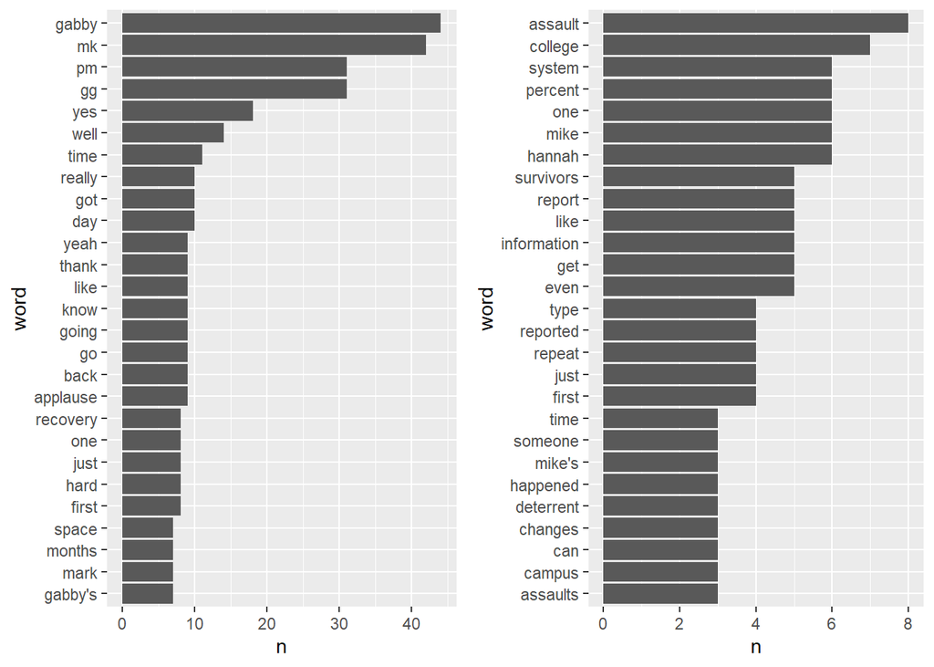

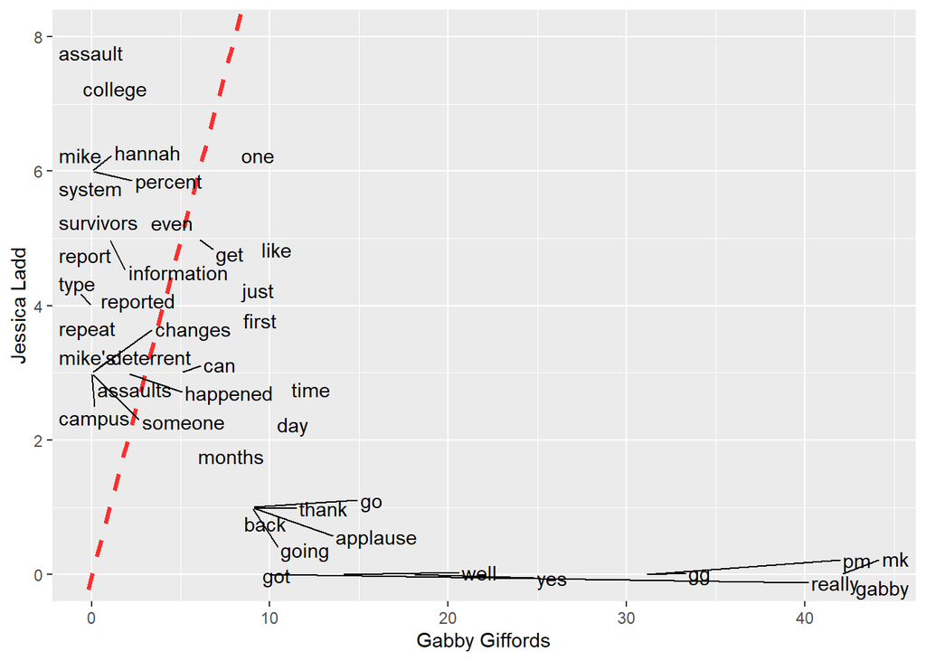

3

In fig. 3, it is evident that both speakers do not have a common vocabulary but have common adjectives and adverbs to describe their words. Examples are like, just, first, going, go and back. Words like yes and got were used by only Gabby Giffords and Jessica Ladd on the other hand was the only one that used words like system, type, information and others.

```
# A tibble: 6,786 × 2
   word        sentiment
   <chr>       <chr>
 1 2-faces     negative
 2 abnormal    negative
 3 abolish     negative
 4 abominable  negative
 5 abominably  negative
 6 abominate   negative
 7 abomination negative
 8 abort       negative
 9 aborted     negative
10 aborts      negative
# … with 6,776 more rows
```

```
# A tibble: 2 × 5
  speaker        sentiment     n total percent
  <chr>          <chr>     <int> <int>   <dbl>
1 Gabby Giffords positive    121   208   58.2
2 Jessica Ladd   positive     14   208    6.73
```

The table above shows that Gabby had a higher percentage(58.2%) of positive sentiment as compared to Jessica’s(6.73%). It also shows that Jessica had more negative sentiments than positive sentiments.

```
# A tibble: 85 × 3
   word          sentiment     n
   <chr>         <chr>     <int>
 1 amazing       positive      2
 2 assault       negative      8
 3 best          positive      5
 4 better        positive      5
 5 challenging   negative      3
 6 clearly       positive      1
 7 controversial negative      1
 8 courage       positive      2
 9 courageous    positive      1
10 crazy         negative      1
# … with 75 more rows
```

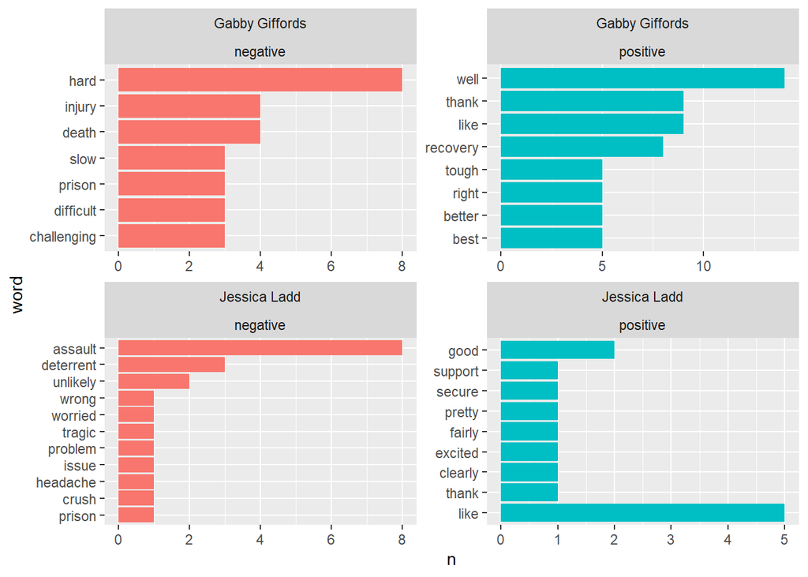

In the Figure, the sentiment with the highest positive and negative occurrences for Gabby Giffords well(14 times) and hard(8 times) respectively and for Jessica Ladd, like for positive and assualt for negative. They appeared 5 and 8 times respectively.

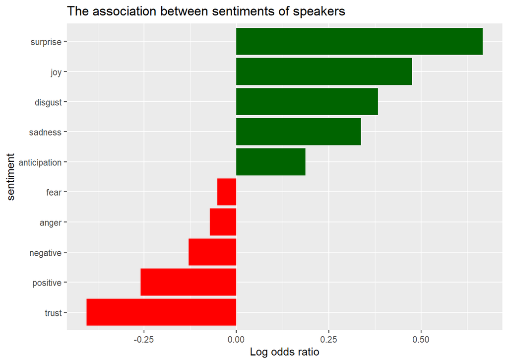

In the tibble above the OR odds shows that Gabby showed more sentiments in Surprise, joy, disgust, sadness, and anticipation than Jessica who showed fear, anger, negative, positive and trust as her sentiments in her Ted talk.

In conclusion, based on the evident produced and speeches by both speakers we can conclude that Gabby Giffords was out to encourage and spur people on with Her Ted talk whereas Jessica Ladd was a cry for help hence getting more negative sentiments than positives.